# Visualizing partial correlations with 3 variables

- Show All Code
- Hide All Code
- View Source

Visualization

Partial correlation

Author

Tyler Grimes

Published

January 5, 2024

Consider three variables $x$, $y$, and $z$. The correlation between $x$ and $y$ is the linear association between them (a straight line in a scatter plot). But what if we think $z$ is a confounder and want to condition on it? The partial correlation between $x$ and $y$ **given** $z$ is a way to account for the value of $z$ when looking at the linear association between $x$ and $y$, but what does it look like? Furthermore, what does it mean if the partial correlation is zero?

Let’s simulate some data and take a look. In these data, $x$ and $y$ are conditionally independent given $z$.

```
flowchart TD
    z --> x
    z --> y
```

```r
library(tidyverse)
library(ppcor)
```

```r
n = 200
sigma = 0.05

set.seed(0)
z = rnorm(n)
x = z + rnorm(n, sigma)
y = z + rnorm(n, sigma)
x.groups = cut(x, breaks = 9)
z.groups = cut(z, breaks = 9)
levels(x.groups) = paste0("x in ", levels(x.groups))
levels(z.groups) = paste0("z in ", levels(z.groups))
df = tibble(x, y, z, x.groups, z.groups)
```

The correlation between $x$ and $y$ and partial correlation given $z$ is computed below. We see the correlation is fairly strong but the partial correlation is near zero.

```r
cor(df$x, df$y)
```

```
[1] 0.5094733
```

```r
ppcor::pcor(df[, 1:3])$estimate[1, 2]
```

```
[1] 0.03041614
```

```r
# Note: can also calculate partial correlation from the pairwise correlations:
r_yx = sqrt(summary(lm(y ~ x))$r.sq) # or use cor(x, y).
r_yz = sqrt(summary(lm(y ~ z))$r.sq)
r_xz = sqrt(summary(lm(x ~ z))$r.sq)
r_yx.z = (r_yx - r_yz * r_xz) / sqrt((1 - r_yz^2) * (1 - r_xz^2))
r_yx.z
```

```
[1] 0.03041614
```

To *see* the partial correlation, we need to look at $x$ and $y$ within a small window of values for $z$. The second plot below shows 9 windows, sliding from smaller values to larger. This is how to think of conditional associations–and the sliding windows is how to think of “controlling” for the confounder.

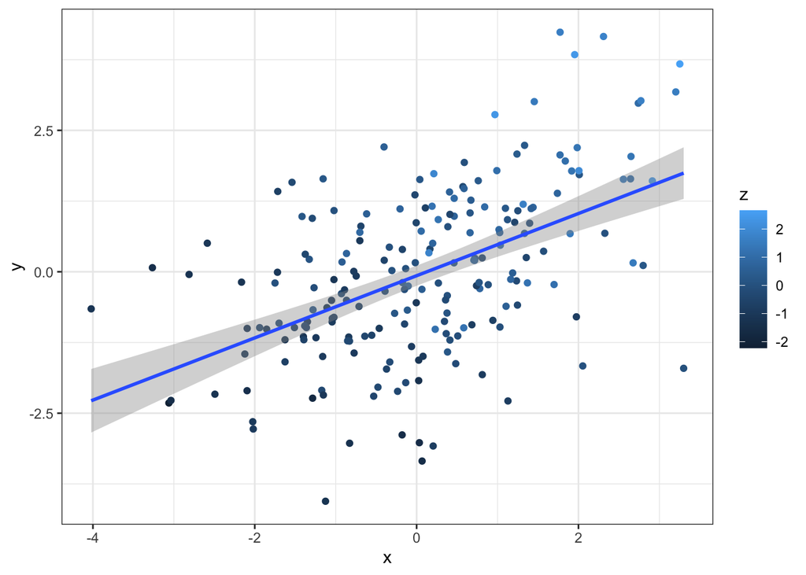

The scatterplot of x and y shows they are correlated.

```r
df %>%
  ggplot(aes(x = x, y = y, color = z)) +
  geom_point() +
  stat_smooth(method = "lm") +
  theme_bw()
```

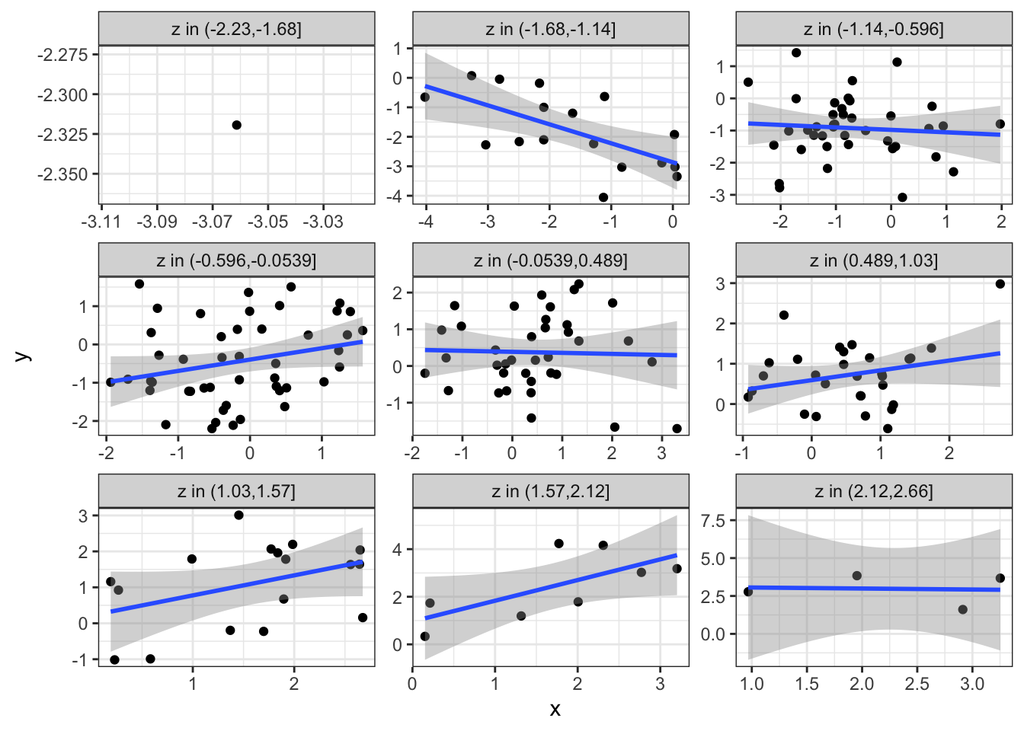

Looking at scatterplots of x and y within different ranges of values for z, the relationship disappears.

```r
g = df %>%
  ggplot(aes(x = x, y = y)) +
  facet_wrap(. ~ z.groups, scales = "free") +
  geom_point() +
  stat_smooth(method = "lm") +
  theme_bw()
g
```

Let’s take a look at the relationship between $z$ and $y$. Note how the partial correlation given $x$ still shows a strong association, and we see the linear association persist across windows of $x$.

```r
cor(df$z, df$y)
```

```
[1] 0.7199976
```

```r
ppcor::pcor(df[, 1:3])$estimate[1, 3]
```

```
[1] 0.5349701
```

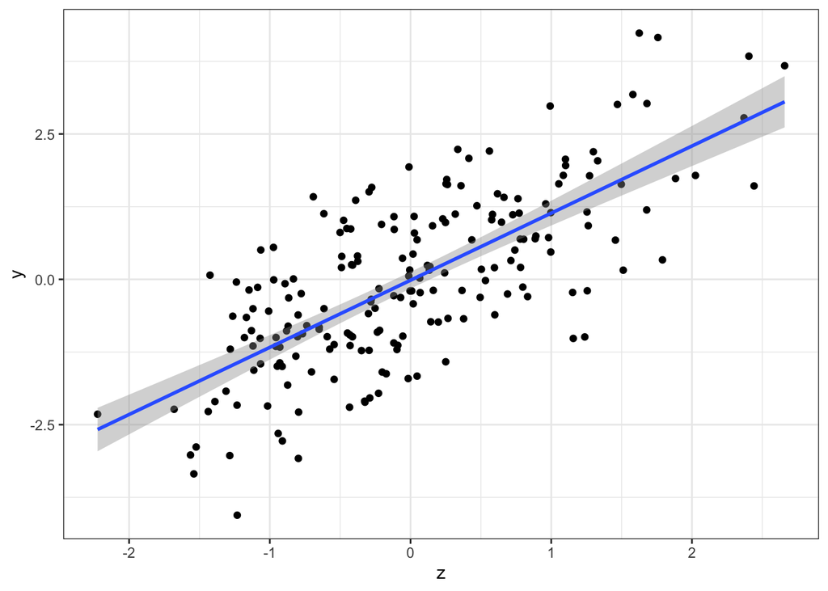

The scatterplot of z and y shows they are correlated.

```r
df %>%
  ggplot(aes(x = z, y = y)) +
  geom_point() +
  stat_smooth(method = "lm") +
  theme_bw()
```

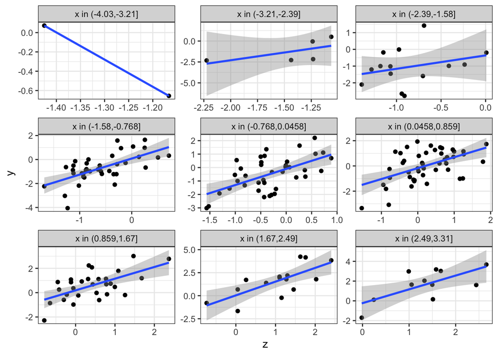

Looking at scatterplots of z and y within different ranges of values for x, the relationship persists.

```r
df %>%
  ggplot(aes(x = z, y = y)) +
  facet_wrap(. ~ x.groups, scales = "free") +
  geom_point() +
  stat_smooth(method = "lm") +
  theme_bw()
```

```r
df %>%
  group_by(x.groups) %>%
  summarize(n = n(),
            `corr_zy|x` = cor(z, y),
            corr_zy = cor(df$z, df$y)) %>%
  as.data.frame()
```

```
              x.groups  n  corr_zy|x   corr_zy
1   x in (-4.03,-3.21]  2 -1.0000000 0.7199976
2   x in (-3.21,-2.39]  5  0.6153158 0.7199976
3   x in (-2.39,-1.58] 14  0.2950542 0.7199976
4  x in (-1.58,-0.768] 38  0.6371105 0.7199976
5 x in (-0.768,0.0458] 39  0.5852865 0.7199976
6  x in (0.0458,0.859] 47  0.5224778 0.7199976
7    x in (0.859,1.67] 29  0.6070441 0.7199976
8     x in (1.67,2.49] 15  0.7324336 0.7199976
9     x in (2.49,3.31] 11  0.6928078 0.7199976
```

## When does partial correlation fail?

In the above example, the correlation between $z$ and $y$ was positive and linear for every value of $x$. What if, instead, the association changed depending on $x$? An interaction effect. In this simulated dataset, $x$ and $y$ have a negative correlation if $z < 0$ and a positive correlation if $z \geq 0$.

**TipThink**

Given the relationship described above, what would we expect the scatterplot of $x$ and $y$ to look like? What about the scatterplots across windows of $z$? What value do we expect the partial correlation of $x$ and $y$ given $z$ to be?

```r
# July 02, 2024
set.seed(0)
x = rnorm(n)
z = rnorm(n)
y = (-1)^(z < 0) * x + rnorm(n, sigma)
x.groups = cut(x, breaks = 9)
z.groups = cut(z, breaks = 9)
levels(x.groups) = paste0("x in ", levels(x.groups))
levels(z.groups) = paste0("z in ", levels(z.groups))
df = tibble(x, y, z, x.groups, z.groups)
```

```r
cor(df$x, df$y)
```

```
[1] 0.09657089
```

```r
ppcor::pcor(df[, 1:3])$estimate[1, 3]
```

```
[1] 0.01930732
```

```r
df %>%
  group_by(z.groups) %>%
  summarize(n = n(),
            `corr_xy|z` = cor(x, y),
            corr_xy = cor(df$x, df$y)) %>%
  as.data.frame()
```

```
              z.groups  n  corr_xy|z    corr_xy
1   z in (-2.91,-2.22]  1         NA 0.09657089
2   z in (-2.22,-1.53] 12 -0.9033113 0.09657089
3  z in (-1.53,-0.848] 29 -0.6202951 0.09657089
4 z in (-0.848,-0.162] 40 -0.7262352 0.09657089
5  z in (-0.162,0.524] 58  0.4046969 0.09657089
6    z in (0.524,1.21] 34  0.7398319 0.09657089
7      z in (1.21,1.9] 21  0.9325690 0.09657089
8      z in (1.9,2.58]  3  0.2854700 0.09657089
9     z in (2.58,3.27]  2 -1.0000000 0.09657089
```

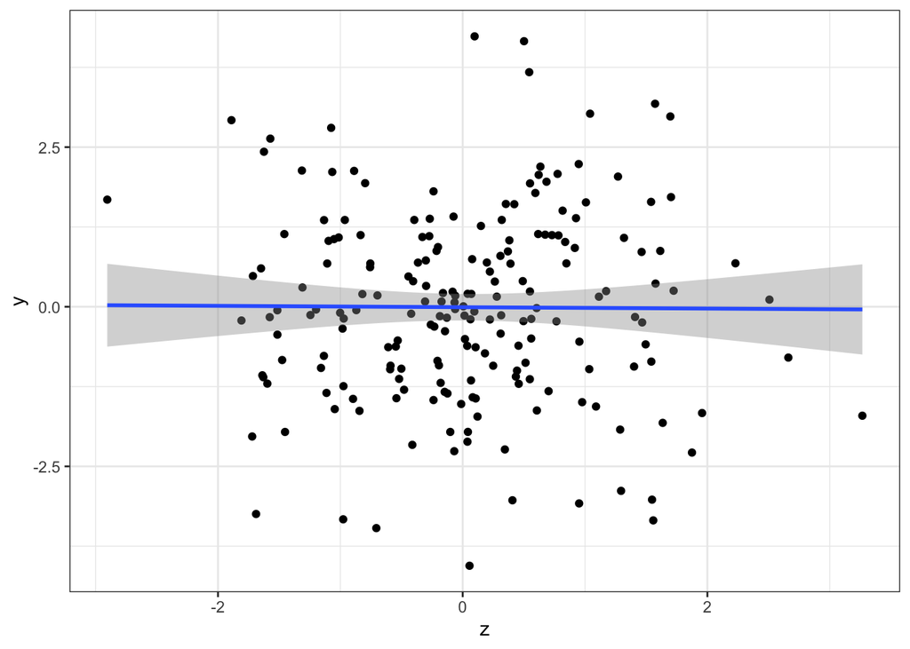

```r
df %>%
  ggplot(aes(x = z, y = y)) +
  geom_point() +
  stat_smooth(method = "lm") +
  theme_bw()
```

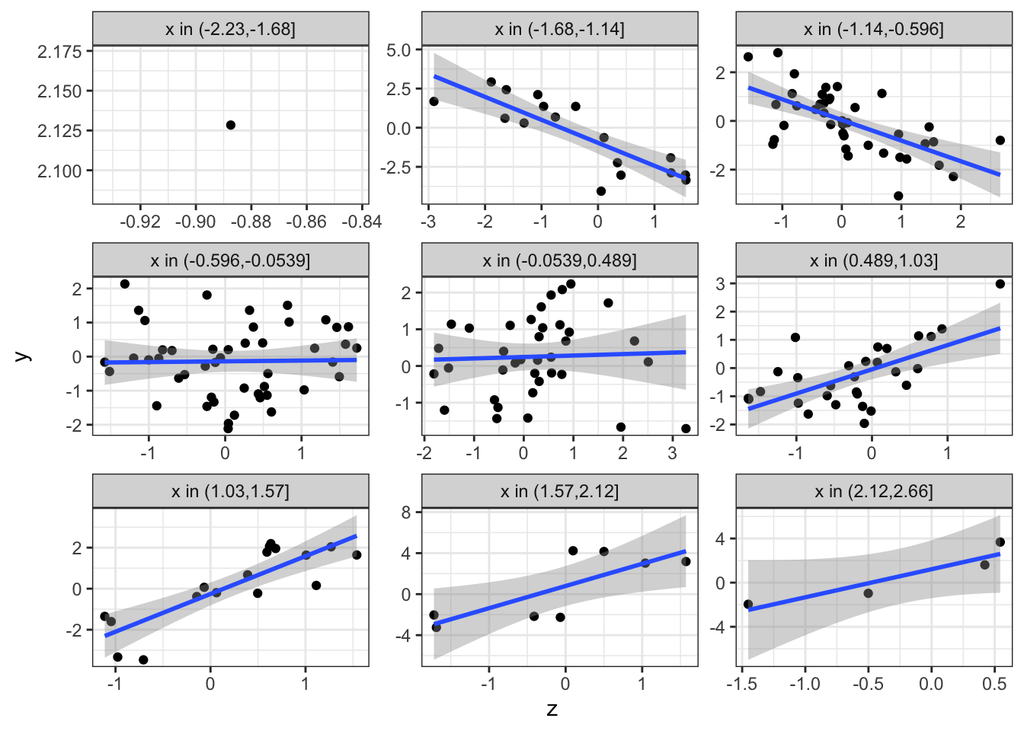

```r
df %>%
  ggplot(aes(x = z, y = y)) +
  facet_wrap(. ~ x.groups, scales = "free") +
  geom_point() +
  stat_smooth(method = "lm") +
  theme_bw()
```

Notice also the linear model suggests the same–no association between $x$ and $y$

```r
summary(lm(y ~ x + z, data = df))
```

```
Call:
lm(formula = y ~ x + z, data = df)

Residuals:
    Min      1Q  Median      3Q     Max
-3.8590 -1.0467 -0.0356  1.0217  3.9886

Coefficients:
            Estimate Std. Error t value Pr(>|t|)
(Intercept) -0.00504    0.10536  -0.048    0.962
x            0.15595    0.11433   1.364    0.174
z           -0.01335    0.10574  -0.126    0.900

Residual standard error: 1.489 on 197 degrees of freedom
Multiple R-squared:  0.009406,  Adjusted R-squared:  -0.0006507
F-statistic: 0.9353 on 2 and 197 DF,  p-value: 0.3942
```

However, if we model the interaction, then we see the association.

```r
summary(lm(y ~ x*z, data = df))
```

```
Call:
lm(formula = y ~ x * z, data = df)

Residuals:
    Min      1Q  Median      3Q     Max
-3.6673 -0.6147  0.0309  0.7276  3.6902

Coefficients:
            Estimate Std. Error t value Pr(>|t|)
(Intercept) -0.02679    0.07817  -0.343  0.73217
x            0.23817    0.08506   2.800  0.00562 **
z            0.11263    0.07906   1.425  0.15588
x:z          1.10060    0.08647  12.728  < 2e-16 ***
---
Signif. codes:  0 '***' 0.001 '**' 0.01 '*' 0.05 '.' 0.1 ' ' 1

Residual standard error: 1.104 on 196 degrees of freedom
Multiple R-squared:  0.4577,    Adjusted R-squared:  0.4494
F-statistic: 55.14 on 3 and 196 DF,  p-value: < 2.2e-16
```

Back to top